# 431 Class 16

Thomas E. Love, Ph.D.

2026-10-15

## Today’s Agenda

- Ingesting / Managing some Favorite Movies Data
- Comparing two groups on a **transformed** outcome
- Comparing two groups **adjusting** for a covariate
- Fitting OLS models with two predictors
- Model Parameters, Model Performance comparisons
- Using `estimate_relation()` for…
  - predictions and uncertainty intervals (PIs & CIs)
  - back-transformation of predictions
- Checking Model Diagnostics

## Today’s Packages

```r
love431_url <-
  "https://raw.githubusercontent.com/THOMASELOVE/431-data/refs/heads/main/data/Love-431.R"
```

- OK. Let’s build our R setup…

```r
knitr::opts_chunk$set(comment = NA)

source(love431_url)

library(janitor)
library(naniar)
library(googlesheets4) ## ingest favorite movies from Google Sheets
library(car)
library(easystats)
library(tidyverse)

theme_set(theme_lucid()) ## from easystats
```

## Cleveland Guardians Team Colors?

```r
guards_red <- "#E50022"
guards_navy <- "#00358D"
```

Source: https://teamcolorcodes.com/.

```r
cream <- "#FFFCD8"
```

# Data Ingest and Management

## Importing Data on Favorite Movies

```r
gs4_deauth() # indicates to Google Drive that you're reading a public file

url_movies <- "https://docs.google.com/spreadsheets/d/1LJdlS1JUYQqJidrnkJ5OmFZr009g25oiZkvtZXhXXlc"
## this is movies_2026-10-13 from our shared drive

mov_raw <- read_sheet(url_movies, na = c("", "NA"))
```

```
✔ Reading from "movies_2026-10-13".
```

```
✔ Range 'movies_2026-10-13'.
```

```r
dim(mov_raw)
```

```
[1] 282  97
```

## Data Cleanup for Today

```r
movies <- mov_raw |>
  select(mov_id, bw_rating, imdb_stars, gend_1, gend_2, gend_3,
         rt_audience, movie) |>
  mutate(across(where(is.character), as_factor),
         movie = as.character(movie),
         mov_id = as.character(mov_id))

movies |> head()
```

```
# A tibble: 6 × 8
  mov_id bw_rating imdb_stars gend_1 gend_2 gend_3 rt_audience movie
  <chr>      <dbl>      <dbl> <fct>  <fct>  <fct>        <dbl> <chr>
1 M-001          1        8.4 M      M      F               93 3 Idiots
2 M-002          3        8   M      F      F               92 8 1/2
3 M-003          3        7.4 M      F      M               69 10 Things I Hate…
4 M-004          3        7.3 F      F      F               74 20th Century Wom…
5 M-005         NA        7.6 M      F      M               89 300
6 M-006          0        8.3 M      M      M               89 2001: A Space Od…
```

## Missingness?

```r
miss_var_summary(movies) |> filter(n_miss > 0)
```

```
# A tibble: 2 × 3
  variable    n_miss pct_miss
  <chr>        <int>    <num>
1 bw_rating       17     6.03
2 rt_audience      3     1.06
```

```r
miss_case_table(movies)
```

```
# A tibble: 3 × 3
  n_miss_in_case n_cases pct_cases
           <int>   <int>     <dbl>
1              0     265     94.0
2              1      14      4.96
3              2       3      1.06
```

## Which movies have missing data?

```r
movies |> filter(!complete.cases(bw_rating, rt_audience)) |>
  select(mov_id, bw_rating, rt_audience, movie)
```

```
# A tibble: 17 × 4
   mov_id bw_rating rt_audience movie
   <chr>      <dbl>       <dbl> <chr>
 1 M-005         NA          89 300
 2 M-013         NA          NA Ananda Bhairavi
 3 M-018         NA          NA B for Busy (Al qing shen hua)
 4 M-044         NA          NA Chinese Doctors (Zhong guo yi sheng)
 5 M-080         NA          84 The Garden of Words (Kotonoha no niwa)
 6 M-085         NA          85 Gifted Hands: The Ben Carson Story
 7 M-086         NA          28 The Gingerdead Man
 8 M-103         NA          80 Harlem Nights
 9 M-117         NA          65 House Party 2
10 M-134         NA          90 Jab We Met (When We Met)
11 M-151         NA          91 The Legend of 1900 (La leggenda del pianista su…
12 M-155         NA          96 Like Stars on Earth (Taare Zameen Par)
13 M-165         NA          56 Loving Adults (Kærlighed for voksne)
14 M-181         NA          89 Miracle in Cell No. 7 (7-beon-bang-ui seon-mul)
15 M-199         NA          77 Om Shanti Om (Peace Be With You)
16 M-254         NA          90 Still Walking (Aruitemo aruitemo)
17 M-273         NA          88 Waterloo Bridge
```

## How to deal with missing data?

- Solution today: complete case analysis
- Solution coming soon: (single or multiple) imputation

```r
movies_cc <- movies |> drop_na()

dim(movies_cc)
```

```
[1] 265   8
```

## Bechdel-Wallace Rating

Bechdel-Wallace scores<sup>1</sup> range from 0 to 3, and are a count of how many of these standards are met by the movie:

1. It has to have at least two named women in it.
2. Who talk to each other
3. About something besides a man.

A passing score is 3, anything less doesn’t pass the test.

- We’ll create `bw_test` to show Pass or Fail.
[^1]: Here is a [video explaining the Bechdel-Wallace test](https://feministfrequency.com/video/the-bechdel-test-for-women-in-movies/).

## Star Genders

`gend_1`, `gend_2` and `gend_3` represent the genders (M or F) played in the movie by each of the first three listed stars on IMDB.

- We’ll create a variable called `females` to count the number of female stars (0-3).

## Code to create new variables

```r
movies_cc <- movies_cc |>
  mutate(bw_test = factor(bw_rating == 3),
         bw_test = fct_recode(bw_test, "Pass" = "TRUE", "Fail" = "FALSE")) |>
  mutate(females = as.numeric(gend_1 == "F") +
           as.numeric(gend_2 == "F") + as.numeric(gend_3 == "F"))
```

### Checking our cleaning

```r
movies_cc |> select(mov_id, bw_test, bw_rating, females, gend_1, gend_2, gend_3) |>
  head()
```

```
# A tibble: 6 × 7
  mov_id bw_test bw_rating females gend_1 gend_2 gend_3
  <chr>  <fct>       <dbl>   <dbl> <fct>  <fct>  <fct>
1 M-001  Fail            1       1 M      M      F
2 M-002  Pass            3       2 M      F      F
3 M-003  Pass            3       1 M      F      M
4 M-004  Pass            3       3 F      F      F
5 M-006  Fail            0       0 M      M      M
6 M-007  Pass            3       2 F      M      F
```

## Tabulating the New Variables

```r
movies_cc |> tabyl(bw_test, females) |>
  adorn_totals(where = c("row", "col")) |>
  adorn_title()
```

```
         females
 bw_test       0   1  2  3 Total
    Fail      41  68  5  0   114
    Pass      17  76 44 14   151
   Total      58 144 49 14   265
```

Let’s put Pass before Fail in the `bw_test` variable when we fit models:

```r
movies_cc <- movies_cc |> mutate(bw_test = fct_relevel(bw_test, "Pass"))
```

## Today’s Outcome: `imdb_stars`

- 1 star = worst possible, 10 stars = best possible

```r
ggplot(movies_cc, aes(x = imdb_stars)) +
  geom_histogram(binwidth = 0.25, fill = guards_red, col = cream)
```

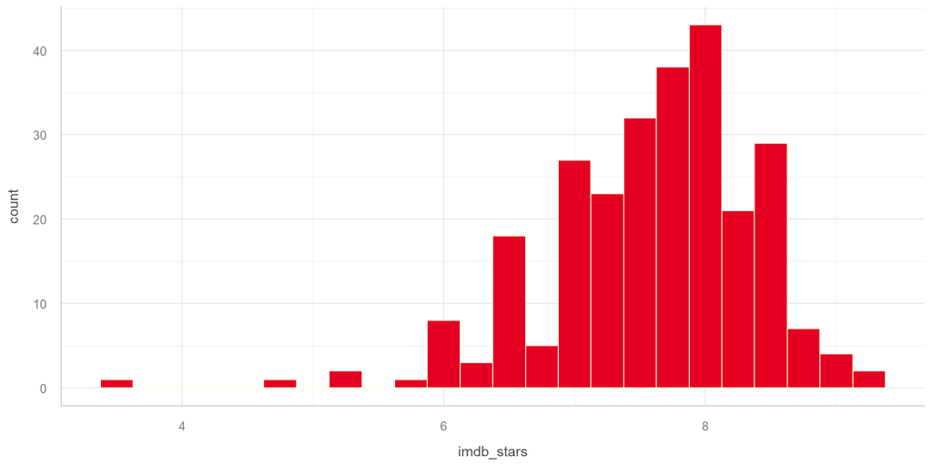

## A Covariate: `rt_audience`

- This is the Popcornmeter, audience scores on 0-100 scale

```r
ggplot(movies_cc, aes(x = rt_audience)) +
  geom_histogram(binwidth = 2, fill = guards_red, col = cream)
```

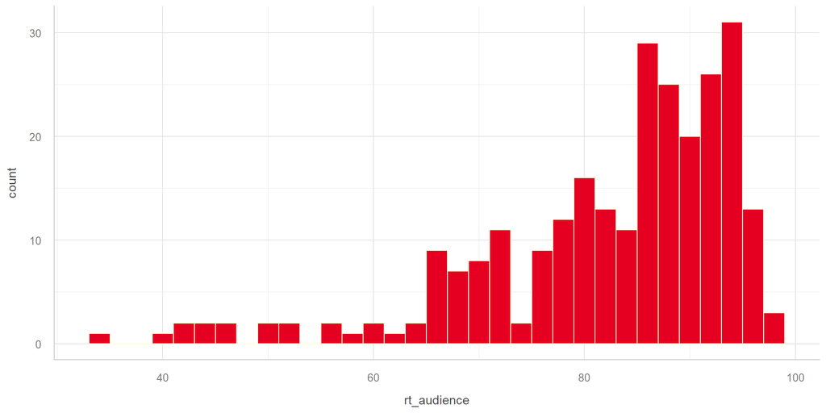

## Audience Reaction Measures

- `imdb_stars` (1 = worst possible, 10 = best possible)

```r
movies_cc |> reframe(lovedist(imdb_stars))
```

```
# A tibble: 1 × 10
      n  miss  mean    sd   med   mad   min   q25   q75   max
  <int> <int> <dbl> <dbl> <dbl> <dbl> <dbl> <dbl> <dbl> <dbl>
1   265     0  7.59 0.781   7.7 0.741   3.6   7.2   8.1   9.3
```

- `rt_audience` (0 to 100 scale: the “Popcornmeter”)

```r
movies_cc |> reframe(lovedist(rt_audience))
```

```
# A tibble: 1 × 10
      n  miss  mean    sd   med   mad   min   q25   q75   max
  <int> <int> <dbl> <dbl> <dbl> <dbl> <dbl> <dbl> <dbl> <dbl>
1   265     0  82.8  12.3    86  10.4    34    78    92    99
```

## Today’s Analyses

```r
movies1 <- movies_cc |> select(mov_id, bw_test, imdb_stars,
                               females, rt_audience, movie)
dim(movies1)
```

```
[1] 265   6
```

1. Do movies which pass the `bw_test` have more (or fewer) `imdb_stars` than movies which do not pass it?
2. Would adjusting for the number of female characters among the first three stars (`females`) change our thinking about the association in analysis 1?
3. Would adjusting for the Rotten Tomatoes Popcornmeter (`rt_audience`) change our thinking about analysis 1?

# Analysis 1

## IMDB Stars by `bw_test` (pass/fail)

```r
ggplot(movies1, aes(x = imdb_stars, y = bw_test)) +
  geom_violin(col = guards_red) +
  geom_boxplot(width = 0.3, col = guards_red, fill = cream, outlier.size = 3) +
  stat_summary(geom = "point", fun = mean, shape = 16, size = 3, col = guards_navy)
```

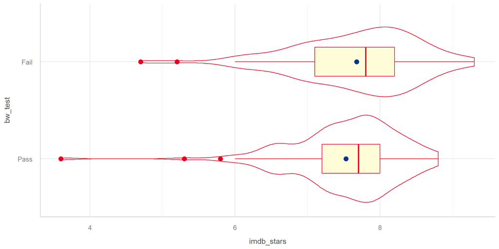

## Analysis 1: Numerical Summary

1. Do movies which pass the `bw_test` have more (or fewer) `imdb_stars` than movies which do not pass it?

```r
movies1 |>
  reframe(lovedist(imdb_stars), .by = bw_test)
```

```
# A tibble: 2 × 11
  bw_test     n  miss  mean    sd   med   mad   min   q25   q75   max
  <fct>   <int> <int> <dbl> <dbl> <dbl> <dbl> <dbl> <dbl> <dbl> <dbl>
1 Fail      114     0  7.68 0.832   7.8 0.741   4.7   7.1   8.2   9.3
2 Pass      151     0  7.53 0.737   7.7 0.593   3.6   7.2   8     8.8
```

- What should we do to compare these means?
  - t test / OLS model, Bayes t test / model, Bootstrap, Wilcoxon rank sum test?

## Box-Cox?

```r
fit0 <- lm(imdb_stars ~ bw_test, data = movies1)
boxCox(fit0, lambda = seq(-2, 5, 1/10))
```

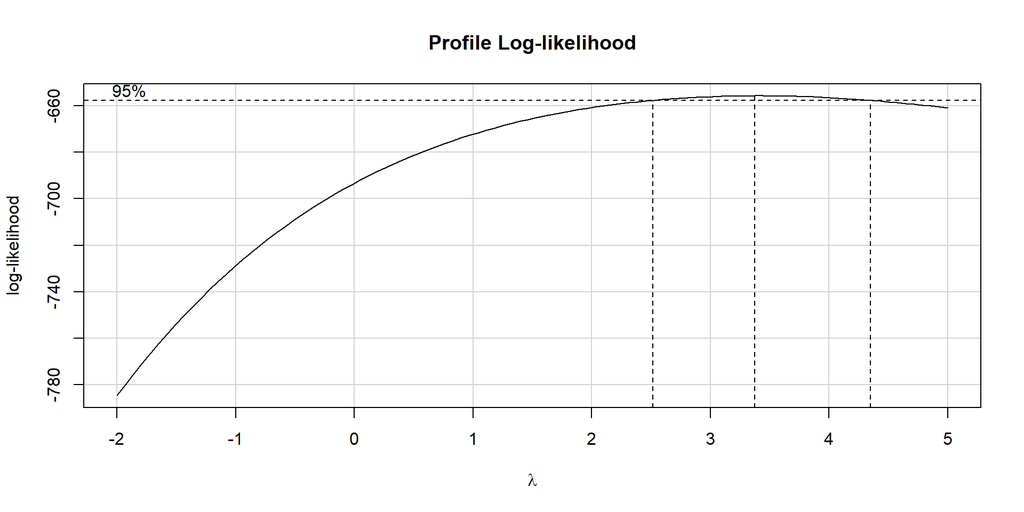

## Squaring the outcome?

```r
ggplot(movies1, aes(x = imdb_stars^2, y = bw_test)) +
  geom_violin(col = guards_red) +
  geom_boxplot(width = 0.3, col = guards_red, fill = cream, outlier.size = 3) +
  stat_summary(geom = "point", fun = mean, shape = 16, size = 3, col = guards_navy)
```

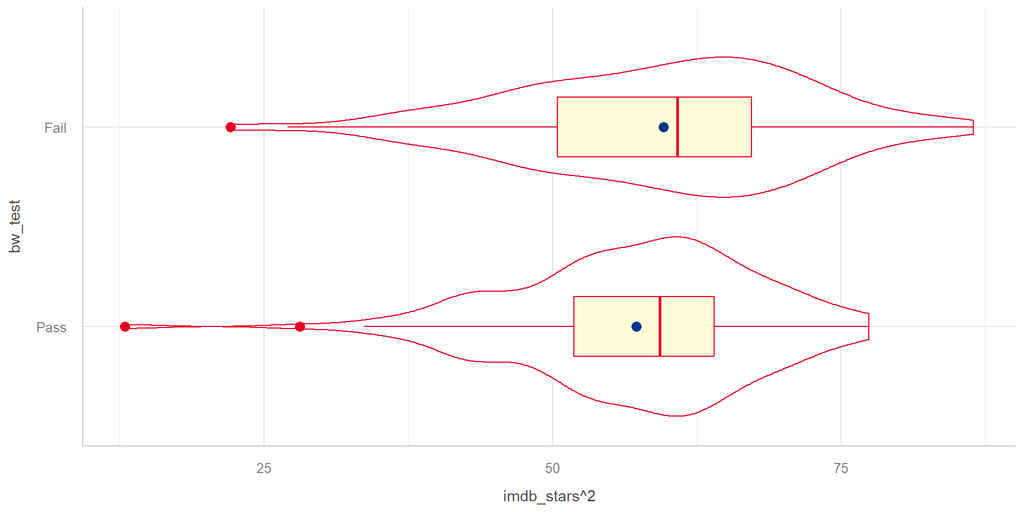

## Cubing the outcome?

```r
ggplot(movies1, aes(x = imdb_stars^3, y = bw_test)) +
  geom_violin(col = guards_red) +
  geom_boxplot(width = 0.3, col = guards_red, fill = cream, outlier.size = 3) +
  stat_summary(geom = "point", fun = mean, shape = 16, size = 3, col = guards_navy)
```

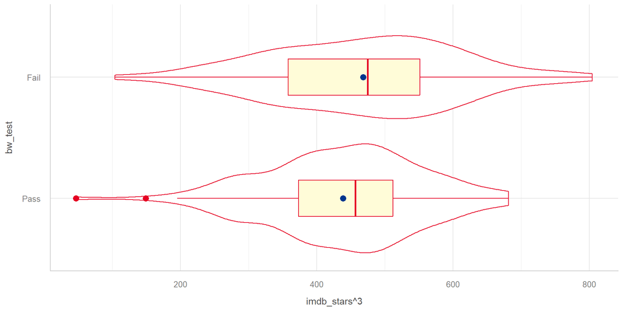

## Tesseracting? (outcome^4)

```r
ggplot(movies1, aes(x = imdb_stars^4, y = bw_test)) +
  geom_violin(col = guards_red) +
  geom_boxplot(width = 0.3, col = guards_red, fill = cream, outlier.size = 3) +
  stat_summary(geom = "point", fun = mean, shape = 16, size = 3, col = guards_navy)
```

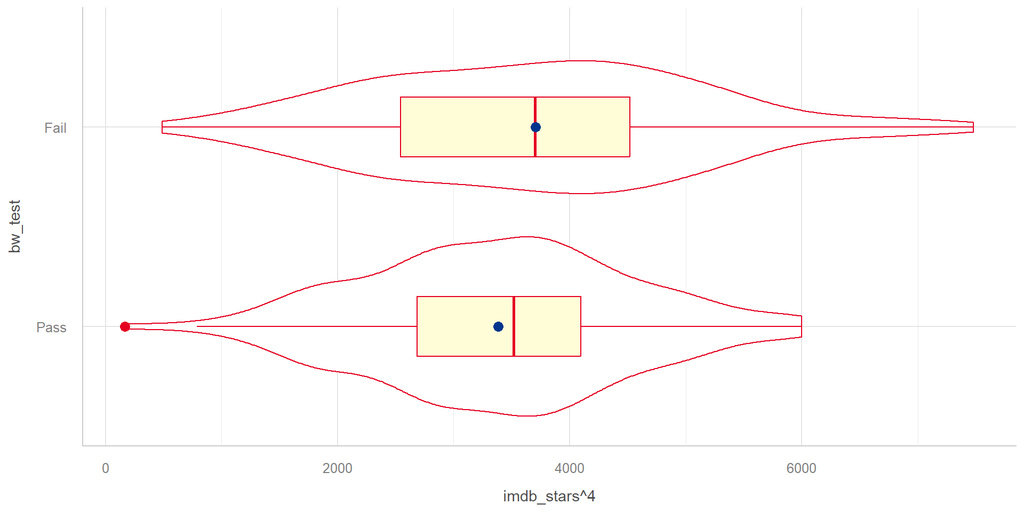

## Which shall we choose?

- If our main goal is to create an interpretable model, then we have a different answer than if our main goal is to transform until the data appear as close to a Normal distribution as possible.
- Most of the time, I stick with simpler transformations, that I can back out of easily, like squares, logs, square roots and inverses.

So here, I’ll go with `imdb_stars` squared…

```r
movies1 <- movies1 |>
  mutate(stars_sq = imdb_stars^2)
```

## OLS Linear Model (t test)

```r
fit1 <- lm(stars_sq ~ bw_test, data = movies1)
model_parameters(fit1, ci = 0.9)
```

```
Parameter      | Coefficient |   SE |         90% CI | t(263) |      p
----------------------------------------------------------------------
(Intercept)    |       57.25 | 0.92 | [55.73, 58.76] |  62.43 | < .001
bw test [Fail] |        2.38 | 1.40 | [ 0.07,  4.69] |   1.70 | 0.090
```

- What does the intercept in `fit1` mean?
- What does the slope of `bw_test` mean in `fit1`?

## OLS Linear Model (t test)

```r
fit1 <- lm(stars_sq ~ bw_test, data = movies1)
model_parameters(fit1, ci = 0.9)
```

```
Parameter      | Coefficient |   SE |         90% CI | t(263) |      p
----------------------------------------------------------------------
(Intercept)    |       57.25 | 0.92 | [55.73, 58.76] |  62.43 | < .001
bw test [Fail] |        2.38 | 1.40 | [ 0.07,  4.69] |   1.70 | 0.090
```

Interpretation?

- Movies which failed the Bechdel-Wallace test had a higher average (squared number of IMDB stars) by 2.38 than did movies which passed the B-W test.

## OLS Linear Model (t test)

```r
fit1 <- lm(stars_sq ~ bw_test, data = movies1)
model_parameters(fit1, ci = 0.9, pretty_names = FALSE)
```

```
Parameter   | Coefficient |   SE |         90% CI | t(263) |      p
-------------------------------------------------------------------
(Intercept) |       57.25 | 0.92 | [55.73, 58.76] |  62.43 | < .001
bw_testFail |        2.38 | 1.40 | [ 0.07,  4.69] |   1.70 | 0.090
```

Interpretation?

- The data are consistent at the 90% confidence level with (0.07, 4.69) more (squared IMDB stars) on average when `bw_test` is Fail, assuming a random sample of movies, and that our model `fit1` is correct.

## Estimating the Effect with `fit1`

```r
estimate_contrasts(fit1, contrast = "bw_test", ci = 0.90)
```

```
Marginal Contrasts Analysis

Level1 | Level2 | Difference |   SE |       90% CI | t(263) |     p
-------------------------------------------------------------------
Fail   | Pass   |       2.38 | 1.40 | [0.07, 4.69] |   1.70 | 0.090

Variable predicted: stars_sq
Predictors contrasted: bw_test
p-values are uncorrected.
```

- Same results as previous slide.
- More useful if we have more than 2 levels of our predictor, naturally.

## Is `fit1` correct?

```r
set.seed(43101)
plot(check_model(fit1, check = c("pp_check", "qq")))
```

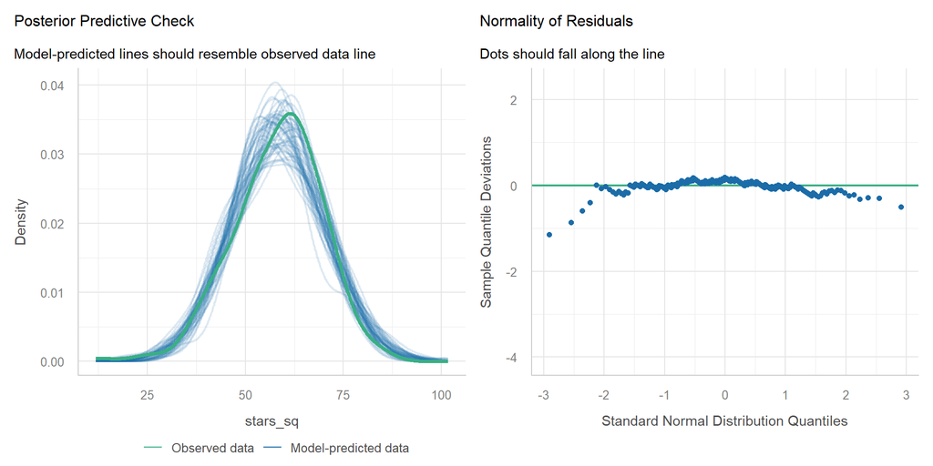

## Let’s keep in the trend…

```r
set.seed(43102)
plot(check_model(fit1, check = c("pp_check", "qq"), detrend = FALSE))
```

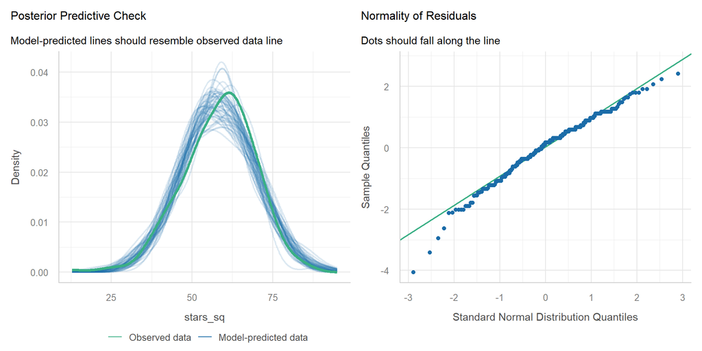

## Which plots are useful?

If we have at least one quantitative predictor, then we consider all five diagnostic plots carefully.

- The 5 Plots include: linearity, homogeneity, influential points, as well as posterior predictive check and Normal Q-Q plot of residuals.
- If we have only a categorical predictor (or predictors), then we will focus on 2 plots: the **posterior predictive check** and the **Normal Q-Q plot of residuals**.

## Useful here?

```r
plot(check_model(fit1, check = c("linearity", "homogeneity")))
```

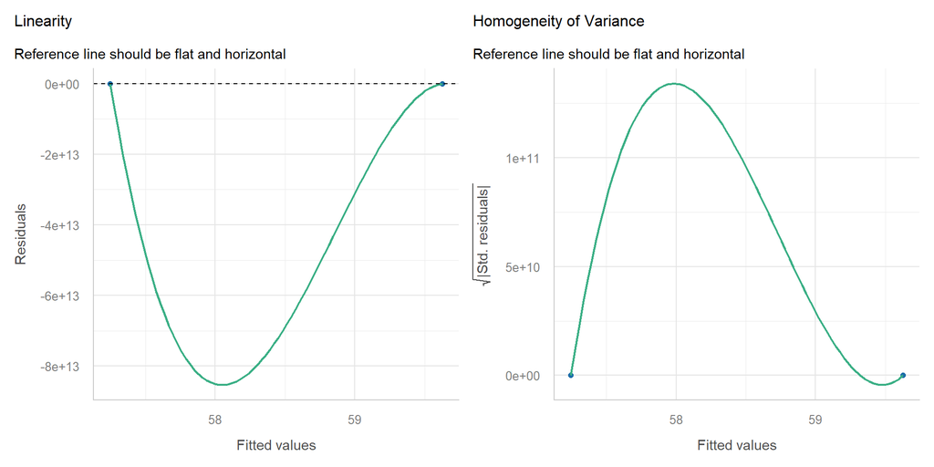

## Useful here?

```r
plot(check_model(fit1, check = "outliers"))
```

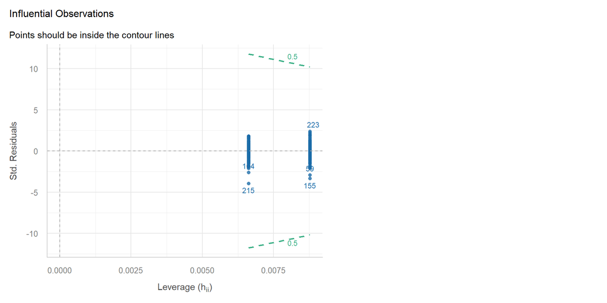

## Performance of the model

```r
model_performance(fit1)
```

```
# Indices of model performance

AIC    |   AICc |    BIC |    R2 | R2 (adj.) |   RMSE |  Sigma
--------------------------------------------------------------
2039.7 | 2039.8 | 2050.4 | 0.011 |     0.007 | 11.225 | 11.268
```

- Can we provide some context for the `Sigma` value?

```r
movies1 |> reframe(lovedist(imdb_stars^2), .by = bw_test)
```

```
# A tibble: 2 × 11
  bw_test     n  miss  mean    sd   med   mad   min   q25   q75   max
  <fct>   <int> <int> <dbl> <dbl> <dbl> <dbl> <dbl> <dbl> <dbl> <dbl>
1 Fail      114     0  59.6  12.3  60.8 11.9   22.1  50.4  67.2  86.5
2 Pass      151     0  57.2  10.4  59.3  8.90  13.0  51.8  64    77.4
```

## Uncertainty Intervals

When making **predictions**, we can build confidence or prediction intervals using our linear regression model.

- We can do so using `estimate_relation()`…
  - **confidence intervals**: describe the mean across a population of subjects with this predictor value
  - **prediction intervals**: describe the best estimate for a single new subject with this predictor value.
- We can also transform the predictions and intervals back to our original outcome (`imdb_stars`).

## Estimate Relation with `fit1`

```r
estimate_relation(fit1, ci = 0.90)
```

```
Model-based Predictions

bw_test | Predicted |   SE |         90% CI
-------------------------------------------
Pass    |     57.25 | 0.92 | [55.73, 58.76]
Fail    |     59.63 | 1.06 | [57.88, 61.37]

Variable predicted: stars_sq
Predictors modulated: bw_test
```

- From `fit1`: Predicted `stars_sq` when `bw_test` is “Pass” = 57.25, with 90% confidence interval (55.73, 58.76).
- Predicted `stars_sq` when `bw_test` is “Fail” = 59.63, with 90% CI (57.88. 61.37).

## Transform and predict `imdb_stars`

1. Refit `fit1` to clarify the outcome transformation to R.

```r
fit1a <- lm((imdb_stars)^2 ~ bw_test, data = movies1)
```

2. Back-transform predictions, with 90% **confidence intervals**.

```r
estimate_relation(fit1a, ci = 0.90, transform = TRUE) ## back-transform
```

```
Model-based Predictions

bw_test | Predicted |       90% CI
----------------------------------
Pass    |      7.57 | [7.47, 7.67]
Fail    |      7.72 | [7.61, 7.83]

Variable predicted: imdb_stars
Predictors modulated: bw_test
```

## Prediction Plot with CIs

```r
plot(estimate_relation(fit1a, ci = 0.90, transform = TRUE)) +
  labs(title = "Predictions from `fit1a` with 90% Confidence Intervals")
```

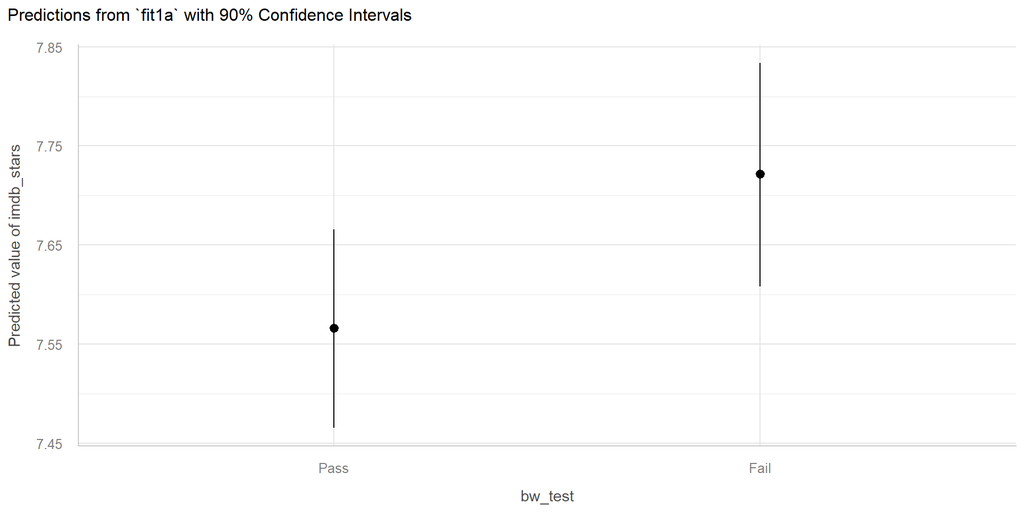

## Prediction Intervals

```r
estimate_relation(fit1a, ci = 0.90, transform = TRUE,
                  predict = "prediction")
```

```
Model-based Predictions

bw_test | Predicted |       90% CI
----------------------------------
Pass    |      7.57 | [6.21, 8.71]
Fail    |      7.72 | [6.40, 8.85]

Variable predicted: imdb_stars
Predictors modulated: bw_test
```

- What is the difference between these prediction intervals and the 90% confidence intervals we saw 2 slides ago?

## Prediction Plot with PIs

```r
plot(estimate_relation(fit1a, ci = 0.90,
                       predict = "prediction", transform = TRUE)) +
  labs(title = "Predictions from `fit1a` with 90% Prediction Intervals")
```

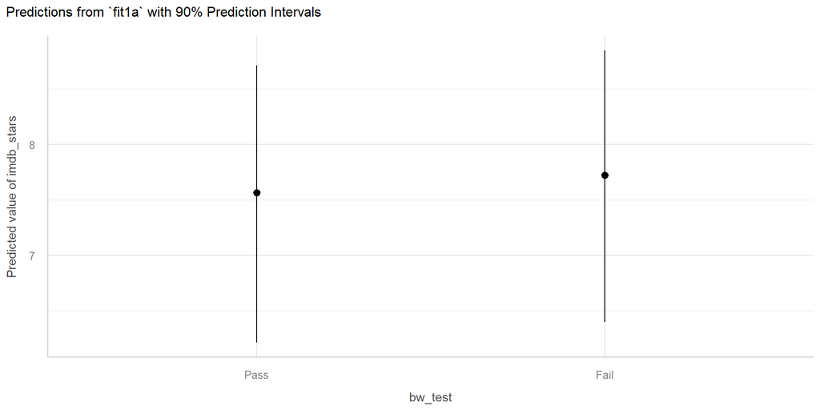

## Uncertainty Intervals

We can build uncertainty intervals using our linear model for *new predictor values*, but if the outcome is transformed, we must back-transform manually.

- For **confidence intervals** for the mean across a population of subjects with (new) specified values of the predictors, use `estimate_expectation()`.
- For **prediction intervals** for a single new subject with (new) specified values of the predictors, use `estimate_prediction()`.

```r
estimate_expectation(fit1, contrast = "bw_test", ci = 0.90,
                     data = tibble(bw_test = c("Pass", "Fail")))
```

```
Model-based Predictions

bw_test | Predicted |   SE |         90% CI
-------------------------------------------
Pass    |     57.25 | 0.92 | [55.73, 58.76]
Fail    |     59.63 | 1.06 | [57.88, 61.37]

Variable predicted: stars_sq
```

`fit1` predictions (and 90% **confidence intervals**) for average `imdb_stars` across many movies…

| `bw_test` | Predicted `imdb_stars` | 90% CI for `imdb_stars` |
| --- | --- | --- |
| Pass | $\sqrt{57.25}$ = 7.57 | (7.47, 7.67) |
| Fail | $\sqrt{59.63}$ = 7.72 | (7.61, 7.83) |

```r
estimate_prediction(fit1, ci = 0.90,
                    data = tibble(bw_test = c("Pass", "Fail")))
```

```
Model-based Predictions

bw_test | Predicted |    SE |         90% CI
--------------------------------------------
Pass    |     57.25 | 11.31 | [38.59, 75.91]
Fail    |     59.63 | 11.32 | [40.95, 78.31]

Variable predicted: stars_sq
```

`fit1` predictions (and 90% **prediction intervals**) for `imdb_stars` for a single new movie…

| `bw_test` | Predicted `imdb_stars` | 90% CI for `imdb_stars` |
| --- | --- | --- |
| Pass | $\sqrt{57.25}$ = 7.57 | (6.21, 8.71) |
| Fail | $\sqrt{59.63}$ = 7.72 | (6.4, 8.85) |

# Standing Break

# Analysis 2

## Adjusting for a Covariate

2. Would adjusting for the number of female characters among the first three stars (females) change our thinking about the association in analysis 1?

Analysis 1 conclusion:

- Movies that failed had 2.38 more (90% CI: 0.07, 4.69) “`imdb_stars` squared” than did movies that passed the Bechdel-Wallace test, assuming our sample is randomly drawn from all movies of interest, and that our regression model for `stars_sq` is correct.

## Fit model `fit2`

Let’s include both the key predictor (`bw_test`) and the covariate (`females`) in the model for `stars_sq`…

```r
fit2 <- lm(stars_sq ~ bw_test + females, data = movies1)
model_parameters(fit2, ci = 0.90, pretty_names = FALSE)
```

```
Parameter   | Coefficient |   SE |         90% CI | t(262) |      p
-------------------------------------------------------------------
(Intercept) |       60.96 | 1.60 | [58.31, 63.61] |  38.03 | < .001
bw_testFail |        0.53 | 1.53 | [-2.00,  3.05] |   0.35 | 0.730
females     |       -2.72 | 0.97 | [-4.32, -1.12] |  -2.81 | 0.005
```

- What does this intercept (60.96) mean?

## Interpreting `fit2` intercept

```r
model_parameters(fit2, ci = 0.90, pretty_names = FALSE)
```

```
Parameter   | Coefficient |   SE |         90% CI | t(262) |      p
-------------------------------------------------------------------
(Intercept) |       60.96 | 1.60 | [58.31, 63.61] |  38.03 | < .001
bw_testFail |        0.53 | 1.53 | [-2.00,  3.05] |   0.35 | 0.730
females     |       -2.72 | 0.97 | [-4.32, -1.12] |  -2.81 | 0.005
```

Intercept = 60.96 specifies the predicted `stars_sq` according to the `fit2` model if **both** `bw_testFail` = 0 **and** `females` = 0.

- `bw_testFail` = 1 if `bw_test` = Fail, and
- `bw_testFail` = 0 if `bw_test` = Pass, so…

## `fit2` Intercept

```r
model_parameters(fit2, ci = 0.90, pretty_names = FALSE)
```

```
Parameter   | Coefficient |   SE |         90% CI | t(262) |      p
-------------------------------------------------------------------
(Intercept) |       60.96 | 1.60 | [58.31, 63.61] |  38.03 | < .001
bw_testFail |        0.53 | 1.53 | [-2.00,  3.05] |   0.35 | 0.730
females     |       -2.72 | 0.97 | [-4.32, -1.12] |  -2.81 | 0.005
```

- Model `fit2` predicts that for a movie with 0 females among the three main stars, and a passing `bw_test` result, the `stars_sq` will be 60.96 (so the predicted `imdb_stars` = $\sqrt{60.96}$ = 7.81 stars.)

## Interpret `bw_test` slope

```r
model_parameters(fit2, ci = 0.90, pretty_names = FALSE)
```

```
Parameter   | Coefficient |   SE |         90% CI | t(262) |      p
-------------------------------------------------------------------
(Intercept) |       60.96 | 1.60 | [58.31, 63.61] |  38.03 | < .001
bw_testFail |        0.53 | 1.53 | [-2.00,  3.05] |   0.35 | 0.730
females     |       -2.72 | 0.97 | [-4.32, -1.12] |  -2.81 | 0.005
```

- What does the slope of `bw_test` mean here?

## Interpret slope of `bw_test`

```r
model_parameters(fit2, ci = 0.90, pretty_names = FALSE)
```

```
Parameter   | Coefficient |   SE |         90% CI | t(262) |      p
-------------------------------------------------------------------
(Intercept) |       60.96 | 1.60 | [58.31, 63.61] |  38.03 | < .001
bw_testFail |        0.53 | 1.53 | [-2.00,  3.05] |   0.35 | 0.730
females     |       -2.72 | 0.97 | [-4.32, -1.12] |  -2.81 | 0.005
```

Suppose we have two movies, each with the **same** number of females in its first three stars, but one movie passed and the other failed the B-W test.

The model `fit2` predicts that the movie which failed will have 0.53 more “`imdb_stars` squared” than the movie which passed, with 90% CI (-2.00, 3.05).

## Interpret `females` slope

```r
model_parameters(fit2, ci = 0.90, pretty_names = FALSE)
```

```
Parameter   | Coefficient |   SE |         90% CI | t(262) |      p
-------------------------------------------------------------------
(Intercept) |       60.96 | 1.60 | [58.31, 63.61] |  38.03 | < .001
bw_testFail |        0.53 | 1.53 | [-2.00,  3.05] |   0.35 | 0.730
females     |       -2.72 | 0.97 | [-4.32, -1.12] |  -2.81 | 0.005
```

- What does the slope of `females` mean?

## Interpret slope of `females`

```r
model_parameters(fit2, ci = 0.90, pretty_names = FALSE)
```

```
Parameter   | Coefficient |   SE |         90% CI | t(262) |      p
-------------------------------------------------------------------
(Intercept) |       60.96 | 1.60 | [58.31, 63.61] |  38.03 | < .001
bw_testFail |        0.53 | 1.53 | [-2.00,  3.05] |   0.35 | 0.730
females     |       -2.72 | 0.97 | [-4.32, -1.12] |  -2.81 | 0.005
```

Suppose we have two movies, each with the **same** B-W test result, but movie A has one more female in its first three stars than movie B.

- The model `fit2` predicts that movie A will have 2.72 fewer “`imdb_stars` squared” than movie B, with 90% CI (1.12, 4.32) fewer “`imdb_stars` squared”.

## `fit1` and `fit2` parameters

What do we learn from this comparison?

```r
model_parameters(fit1, ci = 0.90, pretty_names = FALSE)
```

```
Parameter   | Coefficient |   SE |         90% CI | t(263) |      p
-------------------------------------------------------------------
(Intercept) |       57.25 | 0.92 | [55.73, 58.76] |  62.43 | < .001
bw_testFail |        2.38 | 1.40 | [ 0.07,  4.69] |   1.70 | 0.090
```

```r
model_parameters(fit2, ci = 0.90, pretty_names = FALSE)
```

```
Parameter   | Coefficient |   SE |         90% CI | t(262) |      p
-------------------------------------------------------------------
(Intercept) |       60.96 | 1.60 | [58.31, 63.61] |  38.03 | < .001
bw_testFail |        0.53 | 1.53 | [-2.00,  3.05] |   0.35 | 0.730
females     |       -2.72 | 0.97 | [-4.32, -1.12] |  -2.81 | 0.005
```

- Do the differences in slope for `bw_testFail` make sense?

## Model Performance?

```r
model_performance(fit1)
```

```
# Indices of model performance

AIC    |   AICc |    BIC |    R2 | R2 (adj.) |   RMSE |  Sigma
--------------------------------------------------------------
2039.7 | 2039.8 | 2050.4 | 0.011 |     0.007 | 11.225 | 11.268
```

```r
model_performance(fit2)
```

```
# Indices of model performance

AIC    |   AICc |    BIC |    R2 | R2 (adj.) |   RMSE |  Sigma
--------------------------------------------------------------
2033.8 | 2034.0 | 2048.1 | 0.040 |     0.032 | 11.060 | 11.123
```

- `fit2` has better (smaller) AIC, AICc, BIC, RMSE and Sigma
- `fit2` also has better (larger) R-squared and adjusted R-squared

## Performance Comparison Plot

```r
plot(compare_performance(fit1, fit2))
```

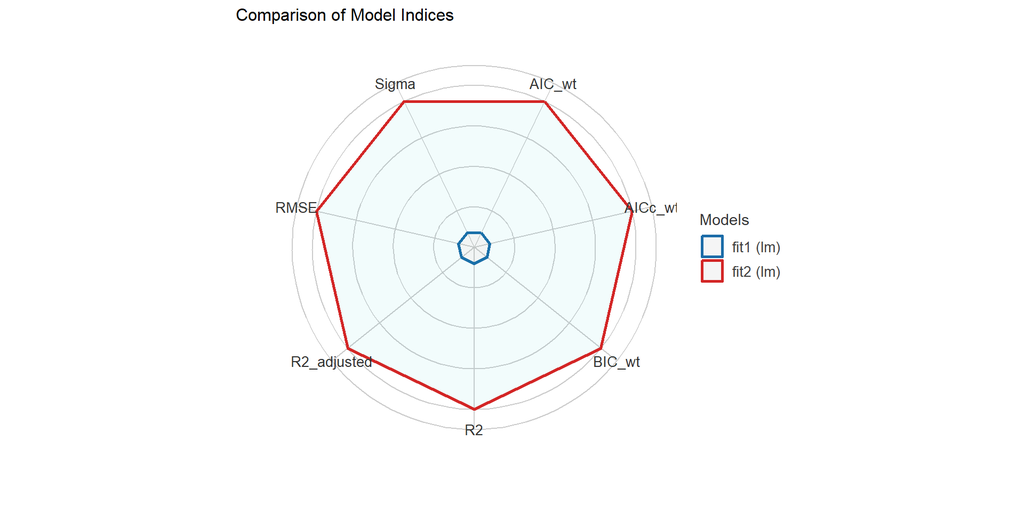

## Diagnostics for `fit2`?

```r
set.seed(43103)
plot(check_model(fit2, check = c("pp_check", "qq"), detrend = FALSE))
```

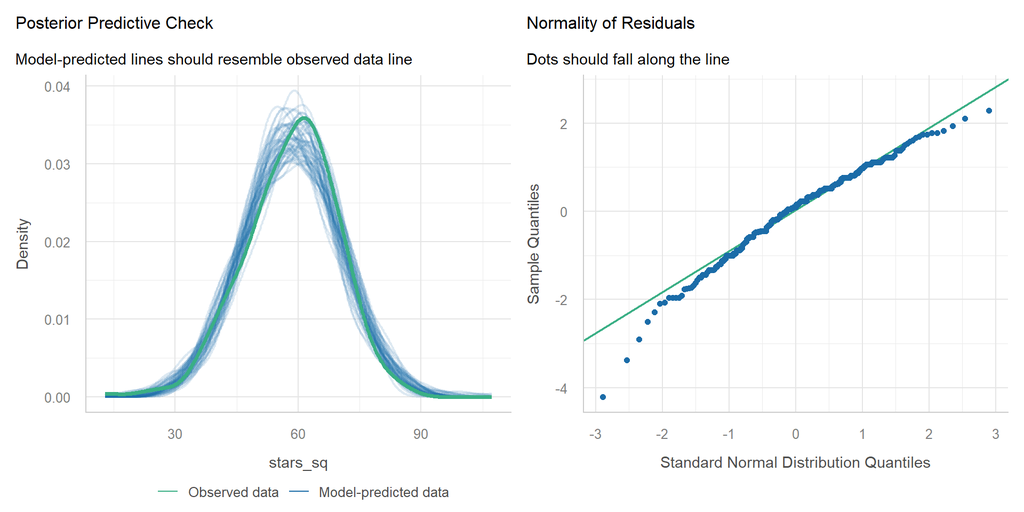

## Predictions with `fit2`?

```r
fit2a <- lm((imdb_stars^2) ~ bw_test + females, data = movies1)
estimate_relation(fit2, ci = 0.9)
```

```
Model-based Predictions

bw_test | females | Predicted |   SE |         90% CI
-----------------------------------------------------
Pass    |       0 |     60.96 | 1.60 | [58.31, 63.61]
Fail    |       0 |     61.49 | 1.24 | [59.45, 63.53]
Pass    |       1 |     58.24 | 0.97 | [56.63, 59.84]
Fail    |       1 |     58.77 | 1.09 | [56.97, 60.56]
Pass    |       2 |     55.52 | 1.10 | [53.71, 57.32]
Fail    |       2 |     56.04 | 1.65 | [53.33, 58.76]
Pass    |       3 |     52.79 | 1.83 | [49.78, 55.81]

Variable predicted: stars_sq
Predictors modulated: bw_test, females
```

## No prediction at Fail, 3 females?

Recall the original data…

```r
movies1 |> tabyl(bw_test, females)
```

```
 bw_test  0  1  2  3
    Pass 17 76 44 14
    Fail 41 68  5  0
```

- With no observations in the (Fail, 3) cell to work with, R won’t make a prediction.

## Back-transform predictions?

```r
fit2a <- lm((imdb_stars^2) ~ bw_test + females, data = movies1)
estimate_relation(fit2a, ci = 0.9, transform = TRUE)
```

```
Model-based Predictions

bw_test | females | Predicted |       90% CI
--------------------------------------------
Pass    |       0 |      7.81 | [7.64, 7.98]
Fail    |       0 |      7.84 | [7.71, 7.97]
Pass    |       1 |      7.63 | [7.53, 7.74]
Fail    |       1 |      7.67 | [7.55, 7.78]
Pass    |       2 |      7.45 | [7.33, 7.57]
Fail    |       2 |      7.49 | [7.30, 7.67]
Pass    |       3 |      7.27 | [7.06, 7.47]

Variable predicted: imdb_stars
Predictors modulated: bw_test, females
```

## `fit2` predictions with CIs

```r
plot(estimate_relation(fit2a, ci = 0.9, transform = TRUE)) +
  labs(title = "Predicted imdb_stars with 90% CIs")
```

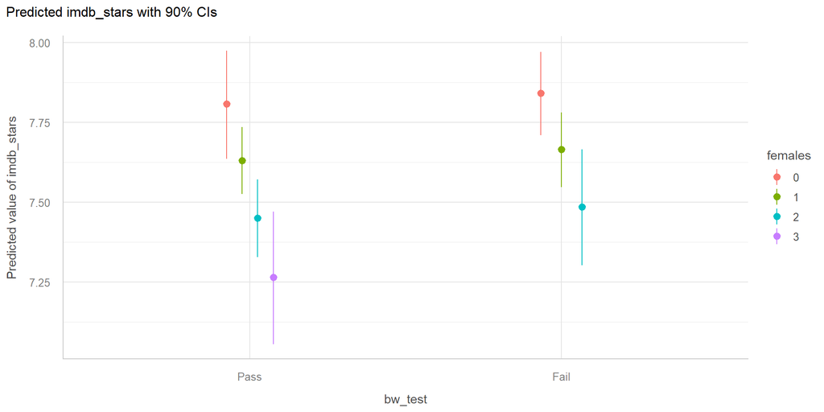

## `fit2` predictions with PIs

```r
plot(estimate_relation(fit2a, ci = 0.9, transform = TRUE,
                       predict = "prediction")) +
  labs(title = "Predicted imdb_stars with 90% PIs")
```

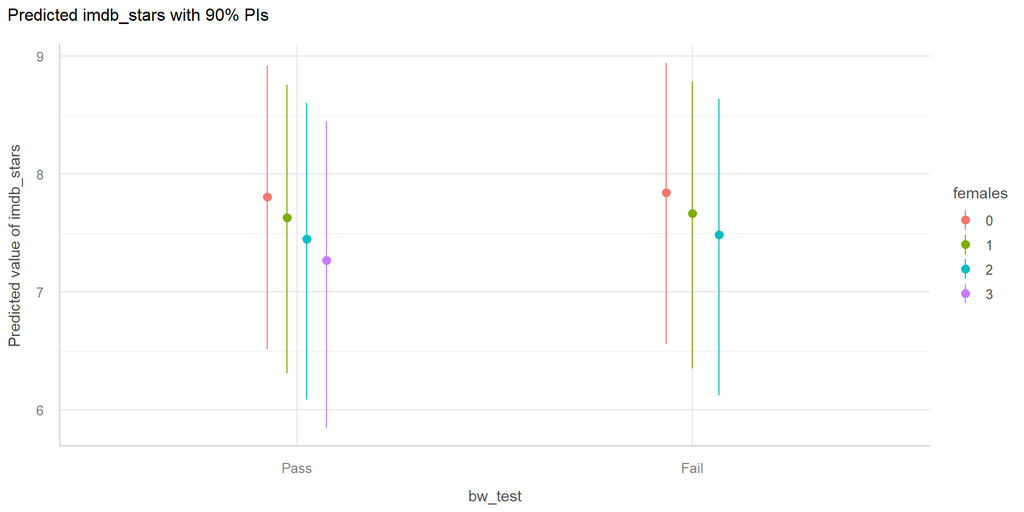

## Other `fit2` Diagnostics?

```r
plot(check_model(fit2, check = c("linearity", "homogeneity")))
```

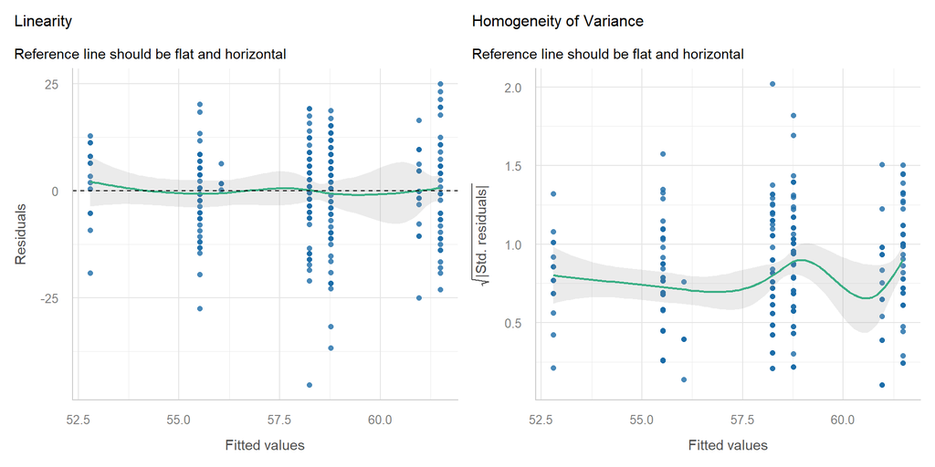

## Other `fit2` Diagnostics?

```r
plot(check_model(fit2, check = c("outliers")))
```

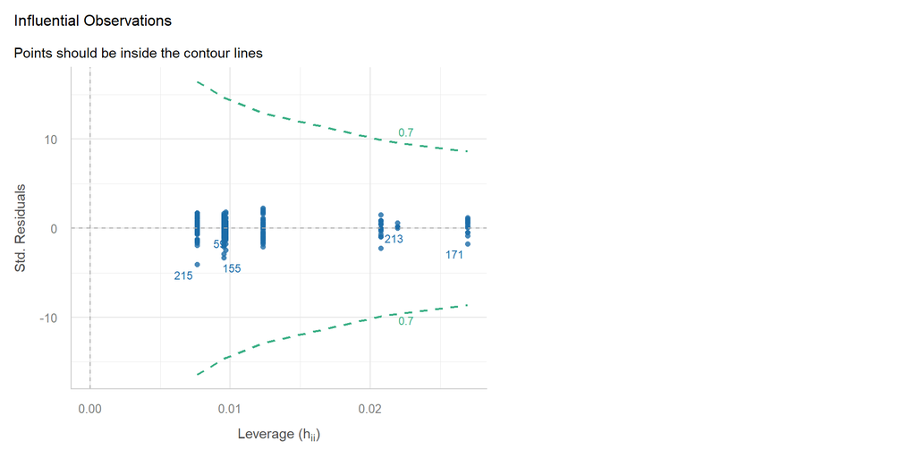

# Analysis 3

## Adjusting for a Covariate

3. Would adjusting for the Rotten Tomatoes Popcornmeter (`rt_audience`) change our thinking about analysis 1?

Analysis 1 conclusion:

- Movies that failed had 2.38 more (90% CI: 0.07, 4.69) “`imdb_stars` squared” than did movies that passed the Bechdel-Wallace test, assuming our sample is randomly drawn from all movies of interest, and that our regression model for `stars_sq` is correct.

## Fit a model (1st try)

Let’s include both the key predictor (`bw_test`) and the covariate (`rt_audience`) in the model for `stars_sq`…

```r
fit3x <- lm(stars_sq ~ bw_test + rt_audience,
            data = movies1)
model_parameters(fit3x, ci = 0.90, pretty_names = FALSE)
```

```
Parameter   | Coefficient |   SE |        90% CI | t(262) |      p
------------------------------------------------------------------
(Intercept) |        0.47 | 3.11 | [-4.66, 5.60] |   0.15 | 0.880
bw_testFail |        1.47 | 0.92 | [-0.05, 2.99] |   1.60 | 0.112
rt_audience |        0.69 | 0.04 | [ 0.63, 0.75] |  18.61 | < .001
```

- What does this intercept (0.47) mean?
- `rt_audience` had minimum 34 and maximum 99, in our data, on the 0-100 scale.

## Centering the Covariate

In the `movies1` data, the variable `rt_audience` has mean 82.82.

- We’ll center our covariate (`rt_audience`) by subtracting its mean.
- This will help our intercept term in the model to mean something, since centered(rt_audience) = 0 means the mean value of `rt_audience`.

## Centering `rt_audience`

```r
movies1 <- movies1 |>
  mutate(rt_aud_c = center(rt_audience),
         rt_aud_c2 = rt_audience - mean(rt_audience))

movies1 |>
  select(mov_id, rt_audience, rt_aud_c, rt_aud_c2, movie) |>
  head(4)
```

```
# A tibble: 4 × 5
  mov_id rt_audience rt_aud_c   rt_aud_c2 movie
  <chr>        <dbl> <dw_trnsf>     <dbl> <chr>
1 M-001           93  10.181132     10.2  3 Idiots
2 M-002           92   9.181132      9.18 8 1/2
3 M-003           69 -13.818868    -13.8  10 Things I Hate About You
4 M-004           74  -8.818868     -8.82 20th Century Women
```

## Interpreting `fit3` intercept

```r
fit3 <- lm(stars_sq ~ bw_test + rt_aud_c, data = movies1)
model_parameters(fit3, ci = 0.90, pretty_names = FALSE)
```

```
Parameter   | Coefficient |   SE |         90% CI | t(262) |      p
-------------------------------------------------------------------
(Intercept) |       57.64 | 0.60 | [56.64, 58.63] |  95.53 | < .001
bw_testFail |        1.47 | 0.92 | [-0.05,  2.99] |   1.60 | 0.112
rt_aud_c    |        0.69 | 0.04 | [ 0.63,  0.75] |  18.61 | < .001
```

Intercept = 57.64 specifies the predicted `stars_sq` according to the `fit3` model if **both** `bw_test` = “Pass” **and** `rt_audience` is at its mean.

## Interpret `bw_test` slope

```r
model_parameters(fit3, ci = 0.90, pretty_names = FALSE)
```

```
Parameter   | Coefficient |   SE |         90% CI | t(262) |      p
-------------------------------------------------------------------
(Intercept) |       57.64 | 0.60 | [56.64, 58.63] |  95.53 | < .001
bw_testFail |        1.47 | 0.92 | [-0.05,  2.99] |   1.60 | 0.112
rt_aud_c    |        0.69 | 0.04 | [ 0.63,  0.75] |  18.61 | < .001
```

Suppose we have two movies, each with the **same** Rotten Tomatoes audience rating, but one movie passed and the other failed the B-W test.

The model `fit3` predicts that the movie which failed will have 1.47 more “`imdb_stars` squared” than the movie which passed, with 90% CI (-0.05, 2.99).

## Interpret `rt_aud_c` slope

```r
model_parameters(fit3, ci = 0.90, pretty_names = FALSE)
```

```
Parameter   | Coefficient |   SE |         90% CI | t(262) |      p
-------------------------------------------------------------------
(Intercept) |       57.64 | 0.60 | [56.64, 58.63] |  95.53 | < .001
bw_testFail |        1.47 | 0.92 | [-0.05,  2.99] |   1.60 | 0.112
rt_aud_c    |        0.69 | 0.04 | [ 0.63,  0.75] |  18.61 | < .001
```

Suppose we have two movies, each with the **same** B-W test result, but movie A has a Rotten Tomatoes Audience Score 1 point higher than movie B.

- The model `fit3` predicts that movie A will have 0.69 more “`imdb_stars` squared” than movie B, with 90% CI (0.63, 0.75).

## `fit1` and `fit3` parameters

```r
model_parameters(fit1, ci = 0.90, pretty_names = FALSE)
```

```
Parameter   | Coefficient |   SE |         90% CI | t(263) |      p
-------------------------------------------------------------------
(Intercept) |       57.25 | 0.92 | [55.73, 58.76] |  62.43 | < .001
bw_testFail |        2.38 | 1.40 | [ 0.07,  4.69] |   1.70 | 0.090
```

```r
model_parameters(fit3, ci = 0.90, pretty_names = FALSE)
```

```
Parameter   | Coefficient |   SE |         90% CI | t(262) |      p
-------------------------------------------------------------------
(Intercept) |       57.64 | 0.60 | [56.64, 58.63] |  95.53 | < .001
bw_testFail |        1.47 | 0.92 | [-0.05,  2.99] |   1.60 | 0.112
rt_aud_c    |        0.69 | 0.04 | [ 0.63,  0.75] |  18.61 | < .001
```

## Model Performance?

```r
model_performance(fit1)
```

```
# Indices of model performance

AIC    |   AICc |    BIC |    R2 | R2 (adj.) |   RMSE |  Sigma
--------------------------------------------------------------
2039.7 | 2039.8 | 2050.4 | 0.011 |     0.007 | 11.225 | 11.268
```

```r
model_performance(fit3)
```

```
# Indices of model performance

AIC    |   AICc |    BIC |    R2 | R2 (adj.) |  RMSE | Sigma
------------------------------------------------------------
1818.5 | 1818.6 | 1832.8 | 0.574 |     0.571 | 7.367 | 7.409
```

- `fit3` has better (smaller) AIC, AICc, BIC, RMSE and Sigma
- `fit3` also has better (larger) R-squared and adjusted R-squared

## Performance Comparison Plot

```r
plot(compare_performance(fit1, fit3))
```

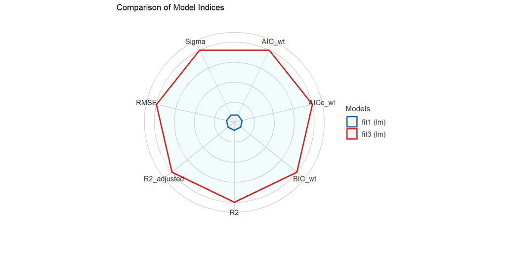

## `fit3` vs. `fit2`?

```r
plot(compare_performance(fit2, fit3))
```

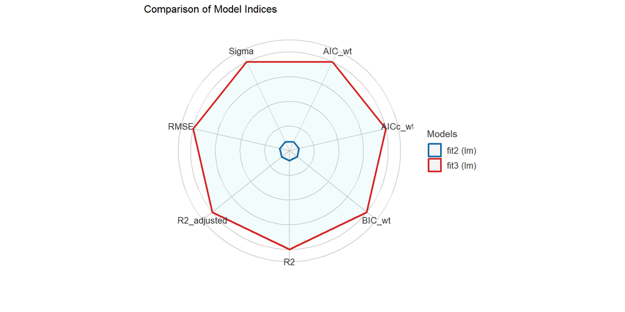

## Predictions with `fit3`?

```r
fit3a <- lm((imdb_stars^2) ~ bw_test + center(rt_audience),
            data = movies1)
estimate_relation(fit3a, ci = 0.9)
```

```
Model-based Predictions

bw_test | rt_audience | Predicted |   SE |         90% CI
---------------------------------------------------------
Fail    |       34.00 |     25.41 | 1.97 | [22.16, 28.65]
Pass    |       41.22 |     28.93 | 1.64 | [26.22, 31.63]
Fail    |       41.22 |     30.39 | 1.72 | [27.56, 33.23]
Pass    |       48.44 |     33.91 | 1.39 | [31.61, 36.21]
Fail    |       48.44 |     35.38 | 1.48 | [32.94, 37.82]
Pass    |       55.67 |     38.90 | 1.16 | [36.99, 40.80]
Fail    |       55.67 |     40.37 | 1.25 | [38.31, 42.42]
Pass    |       62.89 |     43.88 | 0.94 | [42.33, 45.43]
Fail    |       62.89 |     45.35 | 1.03 | [43.64, 47.06]
Pass    |       70.11 |     48.87 | 0.75 | [47.62, 50.11]
Fail    |       70.11 |     50.34 | 0.85 | [48.92, 51.75]
Pass    |       77.33 |     53.85 | 0.63 | [52.81, 54.89]
Fail    |       77.33 |     55.32 | 0.73 | [54.11, 56.53]
Pass    |       84.56 |     58.84 | 0.61 | [57.83, 59.84]
Fail    |       84.56 |     60.31 | 0.69 | [59.16, 61.45]
Pass    |       91.78 |     63.82 | 0.70 | [62.67, 64.98]
Fail    |       91.78 |     65.29 | 0.76 | [64.04, 66.54]
Pass    |       99.00 |     68.81 | 0.87 | [67.38, 70.24]

Variable predicted: imdb_stars
Predictors modulated: bw_test, rt_audience
Predictions are on the power-scale (consider `transform=TRUE`).
```

## Back-transform predictions?

```r
fit3b <- lm((imdb_stars^2) ~ center(rt_audience) + bw_test,
            data = movies1)
estimate_relation(fit3b, ci = 0.9, transform = TRUE)
```

```
Model-based Predictions

rt_audience | bw_test | Predicted |       90% CI
------------------------------------------------
41.22       | Pass    |      5.38 | [5.12, 5.62]
48.44       | Pass    |      5.82 | [5.62, 6.02]
55.67       | Pass    |      6.24 | [6.08, 6.39]
62.89       | Pass    |      6.62 | [6.51, 6.74]
70.11       | Pass    |      6.99 | [6.90, 7.08]
77.33       | Pass    |      7.34 | [7.27, 7.41]
84.56       | Pass    |      7.67 | [7.60, 7.74]
91.78       | Pass    |      7.99 | [7.92, 8.06]
99.00       | Pass    |      8.30 | [8.21, 8.38]
34.00       | Fail    |      5.04 | [4.71, 5.35]
41.22       | Fail    |      5.51 | [5.25, 5.76]
48.44       | Fail    |      5.95 | [5.74, 6.15]
55.67       | Fail    |      6.35 | [6.19, 6.51]
62.89       | Fail    |      6.73 | [6.61, 6.86]
70.11       | Fail    |      7.09 | [6.99, 7.19]
77.33       | Fail    |      7.44 | [7.36, 7.52]
84.56       | Fail    |      7.77 | [7.69, 7.84]
91.78       | Fail    |      8.08 | [8.00, 8.16]

Variable predicted: imdb_stars
Predictors modulated: rt_audience, bw_test
```

## `fit3` predictions with CIs

```r
plot(estimate_relation(fit3b, ci = 0.9, transform = TRUE)) +
  scale_fill_viridis_d() +
  labs(title = "fit3b Predicted imdb_stars with 90% CIs")
```

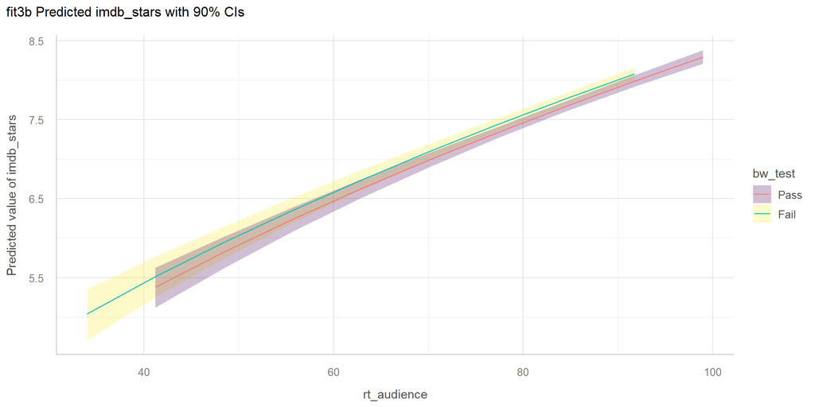

## `fit3b` predictions with PIs

```r
plot(estimate_relation(fit3b, ci = 0.9, transform = TRUE,
                       predict = "prediction")) +
  scale_fill_oi() +
  labs(title = "fit3b Predicted imdb_stars with 90% PIs")
```

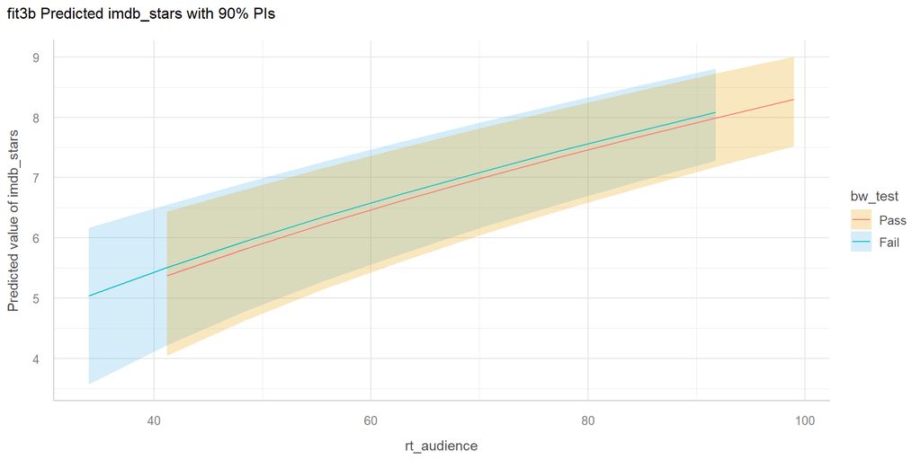

## Diagnostics for `fit3`?

```r
set.seed(43104)
plot(check_model(fit3, check = c("pp_check", "qq"), detrend = FALSE))
```

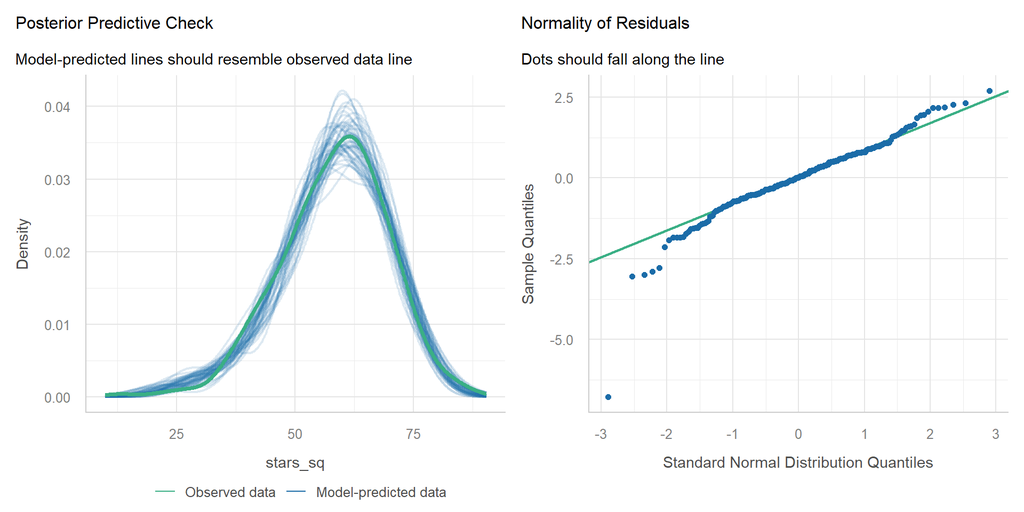

## Other `fit3` Diagnostics?

```r
plot(check_model(fit3, check = c("linearity", "homogeneity")))
```

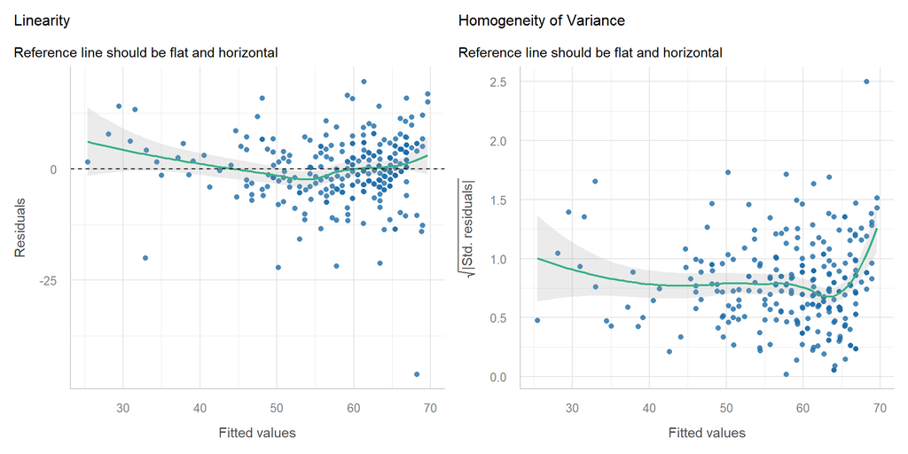

## What movie is the big outlier?

```r
movies1 <- movies1 |>
  mutate(pred3 = fit3$fitted.values, res3 = fit3$resid)
temp <- movies1 |>
  select(mov_id, rt_aud = rt_audience, bw_test, stars_sq,
         pred3, res3, movie) |> arrange(res3)
temp |> head(3) ## three most negative residuals
```

```
# A tibble: 3 × 7
  mov_id rt_aud bw_test stars_sq pred3  res3 movie
  <chr>   <dbl> <fct>      <dbl> <dbl> <dbl> <chr>
1 M-168      96 Fail        22.1  68.2 -46.1 Madea Goes To Jail
2 M-112      72 Pass        28.1  50.2 -22.1 High School Musical 2
3 M-092      83 Pass        36    57.8 -21.8 Godzilla, King of the Monsters
```

```r
temp |> tail(3) ## three most positive residuals
```

```
# A tibble: 3 × 7
  mov_id rt_aud bw_test stars_sq pred3  res3 movie
  <chr>   <dbl> <fct>      <dbl> <dbl> <dbl> <chr>
1 M-175      85 Pass        75.7  59.1  16.5 The Matrix
2 M-238      98 Fail        86.5  69.6  16.9 The Shawshank Redemption
3 M-164      86 Fail        81    61.3  19.7 Lord of the Rings: The Return of t…
```

# Could we make other decisions?

## What if we cubed `imdb_stars`?

```r
movies1 <- movies1 |>
  mutate(stars_cubed = imdb_stars^3)

fit4a <- lm(stars_cubed ~ bw_test + rt_aud_c,
           data = movies1)

set.seed(43105)
plot(check_model(fit4a,
                 check = c("pp_check", "qq"),
                 detrend = FALSE),
     colors = c(guards_navy, guards_red))
```

## What if we cubed `imdb_stars`?

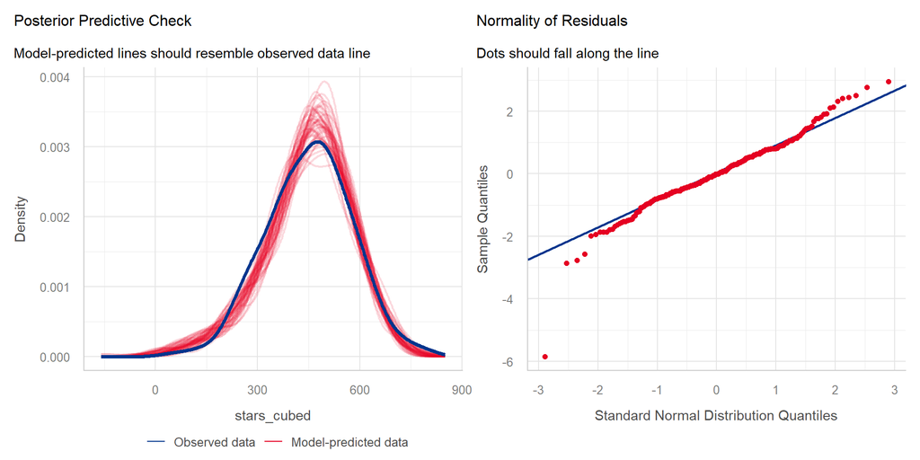

## `imdb_stars` to the 4th power?

```r
movies1 <- movies1 |>
  mutate(stars_4 = imdb_stars^4)

fit5 <- lm(stars_4 ~ bw_test + rt_aud_c,
           data = movies1)

set.seed(43106)
plot(check_model(fit5,
                 check = c("pp_check", "qq"),
                 detrend = FALSE),
     colors = c(guards_navy, guards_red))
```

## `imdb_stars` to the 4th power?

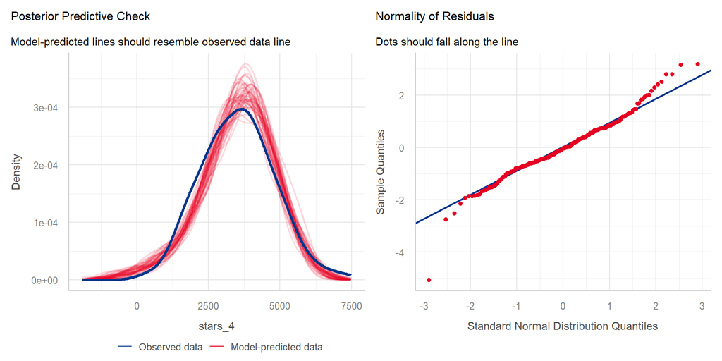

## That’s all, folks!

Is there more we could do? Sure. There always is.